--- title: “570_Final_Project” author: “Ellis Arnold” date: “2023-11-06” output: html_document ---

## Getting the Data

```r
#https://www.propublica.org/datastore/dataset/civilian-complaints-against-new-york-city-police-officers (complaint website)

complaints <- read_csv("/Users/ellisarnold/Desktop/MEJO570FA23/Final Project/Data/Complaints.csv")
```

This data comes from Pro Publica’s Data Store. The data includes information about complaints filed against New York City Police Officers from 1985 to 2020. There are 12,056 unique complaints.

```r
#https://data.cityofnewyork.us/Public-Safety/Police-Precincts/78dh-3ptz (precinct location website)

precincts = st_read("/Users/ellisarnold/Desktop/MEJO570FA23/Final Project/Data/Police Precincts")
```

This shape file comes from a website called NYC Open Data. This website contained the name of each precinct, and its geographic location.

```r
#https://www.prisonpolicy.org/origin/ny/police_precincts.html (from 2010 census, could not find 2020 census population data by police precinct)

pop = read_excel("/Users/ellisarnold/Desktop/MEJO570FA23/Final Project/Data/pop_by_precinct.xlsx")
pop = pop %>% rename("total_pop_2010" = "Total Population (2010 Census)")
```

I scraped this data from the Prison Policy Initiative website. The two columns I used from the website’s original table were the precinct number column and the census population of that precinct, from the 2010 Census. I used census data from this website because when I searched the census website for population data divided by police precinct, I could not find this level of specificity. Ideally, I would use average the precinct population for the Census years 1990, 2000, 2010 and 2020. Since the data spans over these multiple decades, this averaged population would be the most representative for the comparisons I want to make.

## Data Preparation

```r
#number of unique complaints (based off of complaint_id)
length(unique(complaints$complaint_id))
```

```
## [1] 12056
```

```r
#filter for only unique complaints
complaints1 = complaints %>% distinct(complaint_id, .keep_all = TRUE) #more than halves the data!

#renaming columns
complaints1 = complaints1 %>% rename(top_level_cat_complaint = fado_type,
                                     specific_cat_complaint = allegation,
                                     CCRB_finding = board_disposition,
                                     original_contact = contact_reason,
                                     original_contact_outcome = outcome_description,
                                     individual_id = unique_mos_id)

complaints1 = select(complaints1, -shield_no)

#join the data sets
complaints2 = left_join(precincts, complaints1, by="precinct")
complaints2 = left_join(precincts, pop, by=c("precinct"="Precinct"))

#clean new data set
complaints2 = complaints2 %>% select(-shape_leng, -shape_area)
```

## Data Interview

### How many people live in each precinct per complaint?

```r
precinct_group = complaints1 %>% group_by(precinct) %>% summarise(sum = n())
precinct_group = left_join(precinct_group, pop, by=c("precinct"="Precinct"))
precinct_group = precinct_group %>% filter(precinct>0) %>% filter(precinct<150) #take out bogus precincts (precincts that don't exist or are entered as NA)

# How many people live in this precinct per complaint?
precinct_group1 = precinct_group %>% mutate(complaints_by_pop = total_pop_2010 / sum) #how many people / complaint
                                                                                      #lower numbers are worse (there are more complaints with fewer people)
precinct_group1.5 = left_join(complaints2, precinct_group1, by=join_by("precinct"))
precinct_group1.5
```

```
## Simple feature collection with 77 features and 5 fields
## Geometry type: MULTIPOLYGON
## Dimension:     XY
## Bounding box:  xmin: -74.25559 ymin: 40.49613 xmax: -73.70001 ymax: 40.91553
## Geodetic CRS:  WGS84(DD)
## First 10 features:
##    precinct total_pop_2010.x sum total_pop_2010.y complaints_by_pop
## 1         1            66033  65            66033         1015.8923
## 2         5            52683  56            52683          940.7679
## 3         6            62226  69            62226          901.8261
## 4         7            56240  95            56240          592.0000
## 5         9            76443 116            76443          658.9914
## 6        10            50180 101            50180          496.8317
## 7        13            93640  67            93640         1397.6119
## 8        14            20651 149            20651          138.5973
## 9        17            79126  40            79126         1978.1500
## 10       18            54066 122            54066          443.1639
##                          geometry
## 1  MULTIPOLYGON (((-74.04388 4...
## 2  MULTIPOLYGON (((-73.98864 4...
## 3  MULTIPOLYGON (((-73.99968 4...
## 4  MULTIPOLYGON (((-73.97346 4...
## 5  MULTIPOLYGON (((-73.97161 4...
## 6  MULTIPOLYGON (((-74.00139 4...
## 7  MULTIPOLYGON (((-73.98156 4...
## 8  MULTIPOLYGON (((-73.97465 4...
## 9  MULTIPOLYGON (((-73.96421 4...
## 10 MULTIPOLYGON (((-73.99394 4...
```

### What is the spread of complaints / population?

```
##     Min.  1st Qu.   Median     Mean  3rd Qu.     Max.
##    3.125  404.883  754.490 1134.696 1470.232 6468.167
```

### Which precincts have higher volumes of complaints per population?

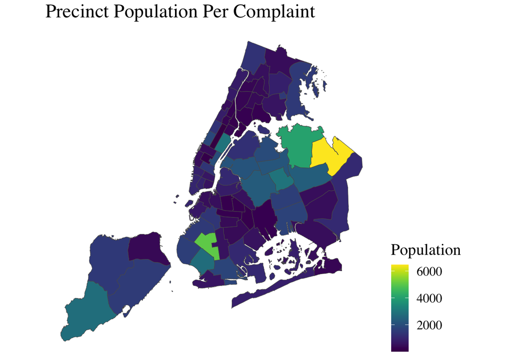

This map is of New York City divided into its 77 police precincts. The visual has accounted for the number of complaints filed in each precinct and its population. The areas of the map with lighter colors represent areas with fewer complaints per person. Darker areas mean there were higher numbers of complaints, after accounting for population. Interestingly, majority of the map is dark, with a few precincts standing out as having low numbers of complaints. The two precincts with the fewest amount of complaints per person are northeastern Queens and Borough Park, Brooklyn. Could these neighborhoods be considered “safer” than others? Is police training more thorough for these units?

### How many NYPD officers have at least one complaint filed against them?

```r
#individuals with a complaint against them
x = complaints1 %>% group_by(individual_id) %>% summarise(sum = n()) %>% arrange(desc(sum))
nrow(x)
```

```
## [1] 3631
```

3,631 NYPD officers have had a complaint filed against them in the time between 1985 and 2020. In 1985 the NYPD employed 26,000 uniformed officers. This number has fluctuated over the years; at the time this data set was last updated the number of NYPD officers had reached 36,000. ***

### How many NYPD officers have had more than one complaint filed against them.

```r
num_officers_w_complaints = nrow(complaints1 %>% group_by(individual_id) %>% summarise(sum = n()))
num_officers_w_more_than_one = nrow(complaints1 %>% group_by(individual_id) %>% summarise(sum=n()) %>% filter(sum>1))

num_officers_w_more_than_one/num_officers_w_complaints
```

```
## [1] 0.700358
```

70% of NYPD officers who received one complaint, later received at least one additional complaint during their time serving. Officers who have violated a rule are likely to do it again.

### Who is the officer with the most complaints?

```r
more_than_1_complaint = complaints1 %>% group_by(individual_id) %>% summarise(sum=n()) %>% filter(sum>1) %>% arrange(desc(sum))

complaints1%>%filter(individual_id==18589)%>%arrange(year_received)
```

```
## # A tibble: 26 × 26
##    individual_id first_name last_name command_now complaint_id month_received
##            <dbl> <chr>      <chr>     <chr>              <dbl>          <dbl>
##  1         18589 Christophe Mccormack DB CED               973              7
##  2         18589 Christophe Mccormack DB CED              2388              6
##  3         18589 Christophe Mccormack DB CED              2766              5
##  4         18589 Christophe Mccormack DB CED              2886              9
##  5         18589 Christophe Mccormack DB CED              3308              7
##  6         18589 Christophe Mccormack DB CED              3349              8
##  7         18589 Christophe Mccormack DB CED              5416              4
##  8         18589 Christophe Mccormack DB CED              6105              1
##  9         18589 Christophe Mccormack DB CED              6120              1
## 10         18589 Christophe Mccormack DB CED              6147              2
## # ℹ 16 more rows
## # ℹ 20 more variables: year_received <dbl>, month_closed <dbl>,
## #   year_closed <dbl>, command_at_incident <chr>, rank_abbrev_incident <chr>,
## #   rank_abbrev_now <chr>, rank_now <chr>, rank_incident <chr>,
## #   mos_ethnicity <chr>, mos_gender <chr>, mos_age_incident <dbl>,
## #   complainant_ethnicity <chr>, complainant_gender <chr>,
## #   complainant_age_incident <dbl>, top_level_cat_complaint <chr>, …
```

Christophe McCormack is the NYPD officer with the most complaints against him. 26 unique complaints have been made over 25 years. Despite ranking at the top of the list for complaints, McCormack has been consistently promoted throughout his years at the NYPD. Since his first complaint in 1990, he has climbed 7 ranks in the policing hierarchy, going from a police officer to Inspector.

### What is the outcome of a complaint?

```
## # A tibble: 11 × 2
##    CCRB_finding                               sum
##    <chr>                                    <int>
##  1 Exonerated                                4318
##  2 Substantiated (Charges)                    939
##  3 Substantiated (Command Discipline A)       204
##  4 Substantiated (Command Discipline B)       139
##  5 Substantiated (Command Discipline)         259
##  6 Substantiated (Command Lvl Instructions)   142
##  7 Substantiated (Formalized Training)        263
##  8 Substantiated (Instructions)                93
##  9 Substantiated (MOS Unidentified)             1
## 10 Substantiated (No Recommendations)          60
## 11 Unsubstantiated                           5638
```

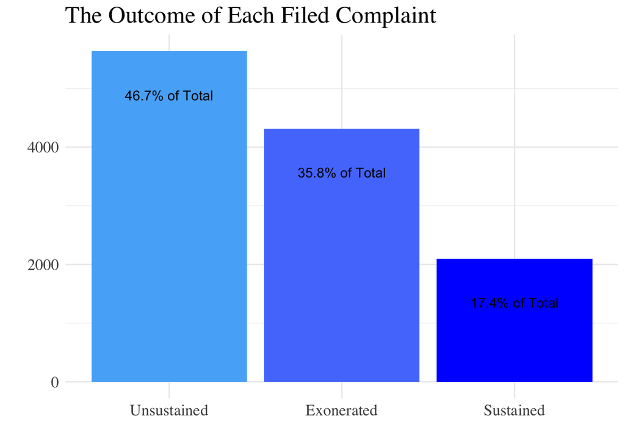

Only 17.4% of all complaints received were sustained, meaning the officer was found to have violated a rule. The remaining 82.6% of reported complaints were either inconclusive or exonerated, meaning the police officer was determined to not have violated a rule, and thus no further action was taken.

### What are the punishments for police officers?

```r
#https://www.nyc.gov/site/ccrb/complaints/complaint-process/police-discipline.page
complaints1 %>% group_by(CCRB_finding) %>% summarise(sum=n()) %>% filter(sum<4318)
```

```
## # A tibble: 9 × 2
##   CCRB_finding                               sum
##   <chr>                                    <int>
## 1 Substantiated (Charges)                    939
## 2 Substantiated (Command Discipline A)       204
## 3 Substantiated (Command Discipline B)       139
## 4 Substantiated (Command Discipline)         259
## 5 Substantiated (Command Lvl Instructions)   142
## 6 Substantiated (Formalized Training)        263
## 7 Substantiated (Instructions)                93
## 8 Substantiated (MOS Unidentified)             1
## 9 Substantiated (No Recommendations)          60
```

939 complaints, that had previously been sustained, resulted in charges being brought to the offending police officer. This is just 7% of the initial number of complaints that were filed. After an officer has been charged, a trial begins at NYPD Headquarters. If the officer has been found guilty, consequences can include loss of vacation days, suspension, or termination from the NYPD. The remainder, and majority, of sustained complaints had less severe consequences, such as required training, policy reminders, or no repercussion recommendation at all. It is unknown if/how many police officers either suspended or terminated due to receiving a complaint. (**Side note: for future story would look into this further. Were people let go becuase of their actions?)

### What is the racial breakdown of complaints received (person accusing)?

```r
complaints_race = complaints1 %>% group_by(complainant_ethnicity) %>% summarise(sum=n()) %>% filter(!is.na(complainant_ethnicity), complainant_ethnicity != "Unknown", complainant_ethnicity !="Refused")

total_known_race_complaints = sum(complaints_race$sum)
complaints_race = complaints_race %>% mutate(prop = sum/total_known_race_complaints)

complaints_race %>% rename(Complaint_Ethnicity = complainant_ethnicity, Filed_Complaints = sum, Proportion_of_Total = prop) %>%
  kbl() %>%
  kable_styling(bootstrap_options = "hover")
```

| Complaint_Ethnicity | Filed_Complaints | Proportion_of_Total |
| --- | --- | --- |
| American Indian | 19 | 0.0019541 |
| Asian | 201 | 0.0206726 |
| Black | 5979 | 0.6149337 |
| Hispanic | 2216 | 0.2279132 |
| Other Race | 231 | 0.0237581 |
| White | 1077 | 0.1107683 |

Approximately 61% of complaints received were filed by an African-American person. In comparison, the average percent of New York City’s population that was black during this time was 23%. Black people are overrepresented in the number of complaints. The two explanations for this are: black people are receiving a higher proportion of unjust policing, or black people report unjust policing more often than any other race. (**Side note, for a complete story I would construct a confidence interval to determine if the percent 61 is significant or not. Would this number ever occur naturally given that black people are treated unfairly in the same proportion all other races are?)

### What are the demographics of an officer who most often receives complaints?

```
## # A tibble: 9 × 3
## # Groups:   mos_gender [2]
##   mos_gender mos_ethnicity     sum
##   <chr>      <chr>           <int>
## 1 M          White            6448
## 2 M          Hispanic         2866
## 3 M          Black            1625
## 4 M          Asian             400
## 5 F          Hispanic          314
## 6 F          White             200
## 7 F          Black             175
## 8 F          Asian              14
## 9 M          American Indian    14
```

At the top of the list with 6448 complaints, the most common officer to receive a complaint is a white male. This demographic received more complaints than all of the other demographic combinations combined. The other combinations paired male and female with Hispanic, Black, Asian, and Native American ethnicities.

### Written Summary

Between the years of 1985 and 2020, 3,631 NYPD officers have received a complaint regarding their policing or behavior towards civilians. This number is slim with respect to the tens of thousands of NYPD officers employed during these decades. Therefore, each complaint should be taken seriously. Submitting a complaint form after a problematic incident with an officer should help deter it from happening again. However, 70% of NYPD officers who received one complaint, later received at least one additional complaint during their time serving. It is clear that officers who have violated a rule are likely to do it again, but why? Are the consequences of receiving a complaint too lenient? Few complaints lead to serious repercussions. Only 17.4% of all complaints received were sustained, meaning the officer was found to have violated a rule. The remaining 82.6% of reported complaints were either inconclusive or exonerated, meaning the police officer was determined to not have violated a rule, and thus no further action was taken. Of the 17.4% of complaints that were sustained, only 939 resulted in charges being brought to the offending officer; this is just 7% of the total number of complaints filed. After an officer has been charged a trial begins at NYPD Headquarters. If the officer is found guilty, next steps can include loss of vacation days, suspension, or termination from the NYPD. The other 1,161 sustained complaints that do not result in charges hold much less severe consequences, such as required training, policy reminders, or even no repercussion recommendation at all. It is unknown if/how many police officers either suspended or terminated due to receiving a complaint. A look at NYPD’s most offending officer provides a specific example of how inappropriate repercussions lead to increased incidents. Christophe McCormack is the NYPD officer with the most complaints against him. 26 unique complaints have been made over 25 years. Despite ranking at the top of the list for complaints, McCormack has been consistently promoted throughout his years at the NYPD. Since his first complaint in 1990, he has climbed 7 ranks in the policing hierarchy, going from a police officer to Inspector.

Proper reverberations is one way to decrease the number of complaints received and deter repeat offenders. However, we can also look to training as a way to keep complaints from ever happening. When broken down by demographic, the most common officer to receive a complaint is a white male. White males received 6,448 complaints, which is more than all of the other demographics combined. The other comparison combinations were paired male or female with Hispanic, Black, Asian, and Native American ethnicities. Also, approximately 61% of complaints were filed by an African-American person. In comparison, the average percent of New York City’s population that was black during this time (1985-2020) was 23%. Black people are incredibly over-represented in the number of complaints. The two explanations for this are: black people are witnessing a higher proportion of unjust policing, or black people report unjust policing more often than any other race. (*Side note, for a complete story I would construct a confidence interval to determine if 61% is significant or not. Would this number ever occur naturally given that black people are treated unfairly in the same proportion all other races are?*) Knowing these facts can change the way New York police officers train. Finally, the visual shows a map of New York City divided into its 77 police precincts. The shading of the map accounts for the number of complaints filed in each precinct and its population. The areas of the map with lighter colors represent areas with fewer complaints per person. Darker areas mean there were higher numbers of complaints, after accounting for population. Interestingly, majority of the map is dark, with a few precincts standing out as having low numbers of complaints. The two precincts with the fewest amount of complaints per person are in northeastern Queens and Borough Park, Brooklyn. Could these neighborhoods be considered “safer” than others? Is police training more thorough for these units?